# Lesson 3

### What to Do First?

Notes: Reading in Data

### Pseudo-Facebook User Data

Notes: It’s not the real Facebook Data

```r
setwd('~/Documents/GitHub/DataAnalystNanodegree/R_test/EDA_Course_Materials/lesson3')
df <- read.delim('pseudo_facebook.tsv')
```

### Histogram of Users’ Birthdays

Notes:

```
## stat_bin: binwidth defaulted to range/30. Use 'binwidth = x' to adjust this.
```

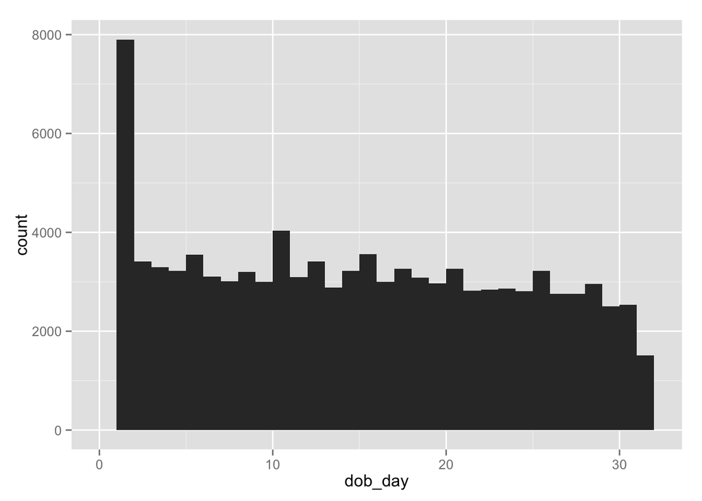

```r
library(ggplot2)
qplot(data = df, x = dob_day)
```

#### What are some things that you notice about this histogram?

Response:

### Moira’s Investigation

Notes:

### Estimating Your Audience Size

Notes:

#### Think about a time when you posted a specific message or shared a photo on Facebook. What was it?

Response:

#### How many of your friends do you think saw that post?

Response:

#### Think about what percent of your friends on Facebook see any posts or comments that you make in a month. What percent do you think that is?

Response:

### Perceived Audience Size

Notes:

### Faceting

Notes:

Response:

### Be Skeptical - Outliers and Anomalies

Notes:

### Friend Count

Notes:

#### How is this plot similar to Moira’s first plot?

Response:

### Limiting the Axes

Notes:

### Exploring with Bin Width

Notes:

### Adjusting the Bin Width

Notes:

### Faceting Friend Count

```r
# What code would you add to create a facet the histogram by gender?
# Add it to the code below.
```

[output not shown]

### Omitting NA Values

Notes:

### Statistics ‘by’ Gender

Notes:

#### Who on average has more friends: men or women?

Response:

#### What’s the difference between the median friend count for women and men?

Response:

#### Why would the median be a better measure than the mean?

Response:

### Tenure

Notes:

### Labeling Plots

Notes:

### User Ages

Notes:

#### What do you notice?

Response:

### The Spread of Memes

Notes:

### Lada’s Money Bag Meme

Notes:

### Transforming Data

Notes:

### Add a Scaling Layer

Notes:

### Likes on the Web

Notes:

### Box Plots

Notes:

### Box Plots, Quartiles, and Friendships

Notes:

#### On average, who initiated more friendships in our sample: men or women?

Response:

### Getting Logical

Notes:

Response:

### Analyzing One Variable

Reflection:

Click **KnitHTML** to see all of your hard work and to have an html page of this lesson, your answers, and your notes!